# Exploring Titanic Dataset with Pandas

### 22/05/2024 by Ryo s10920602

#### **1. Import the Required Libraries**

Code:

```python
import pandas as pd
import matplotlib.pyplot as plt
```

**Explanation of Commands:** These line imports the pandas library and assigns it the alias pd and pyplot module from the matplotlib library and assigns it the alias plt.

**Explanation of Output:** Since this code snippet is importing libraries and setting up aliases, there is no direct output to the console or a file. However, it sets up the environment for subsequent data analysis and visualization tasks. Here’s what happens under the hood:

The pandas and matplotlib.pyplot libraries are loaded into memory, making their functions and classes available for use in your script. Aliases Created: The aliases pd and plt allow you to use shorthand references to these libraries, which makes your code cleaner and easier to write.

#### **2. Load the Dataset**

Code

```python
df = pd.read_csv('titanic.csv')
```

**Explanation of Command:** This line reads a CSV file named titanic.csv into a pandas DataFrame. pd.read_csv() is a function from the pandas library that reads a CSV (Comma-Separated Values) file and converts it into a DataFrame, which is a two-dimensional, size-mutable, and potentially heterogeneous tabular data structure. The file 'titanic.csv' should be in the same directory as your script, or you need to provide the full path to the file. The resulting DataFrame is assigned to the variable df.

**Explanation of Output:** The command does not produce a direct output to the console, but it creates a DataFrame df containing the data from the titanic.csv file. DataFrame Structure: The DataFrame df will have rows and columns corresponding to the data in the CSV file. Each column in the CSV file becomes a column in the DataFrame, and each row in the CSV file becomes a row in the DataFrame.

#### **3. Data Exploration**

Code:

```python
df.head()
```

|  | PassengerId | Survived | Pclass | Name | Sex | Age | SibSp | Parch | Ticket | Fare | Cabin | Embarked |
| --- | --- | --- | --- | --- | --- | --- | --- | --- | --- | --- | --- | --- |
| 0 | 1 | 0 | 3 | Braund, Mr. Owen Harris | male | 22.0 | 1 | 0 | A/5 21171 | 7.2500 | NaN | S |
| 1 | 2 | 1 | 1 | Cumings, Mrs. John Bradley (Florence Briggs Th... | female | 38.0 | 1 | 0 | PC 17599 | 71.2833 | C85 | C |
| 2 | 3 | 1 | 3 | Heikkinen, Miss. Laina | female | 26.0 | 0 | 0 | STON/O2. 3101282 | 7.9250 | NaN | S |
| 3 | 4 | 1 | 1 | Futrelle, Mrs. Jacques Heath (Lily May Peel) | female | 35.0 | 1 | 0 | 113803 | 53.1000 | C123 | S |
| 4 | 5 | 0 | 3 | Allen, Mr. William Henry | male | 35.0 | 0 | 0 | 373450 | 8.0500 | NaN | S |

**Explanation of Command:** This line calls the head() method on the DataFrame df. The head() method returns the first 5 rows of the DataFrame by default. It is a convenient way to quickly inspect the top portion of your DataFrame to understand the structure and content of your dataset.

**Explanation of Output:** The command outputs the first 5 rows of the DataFrame df, displaying a preview of the data. This method is typically used to get a quick look at the data after loading it to ensure it has been read correctly and to understand its structure and types of columns.

```python
df.info()
```

```
<class 'pandas.core.frame.DataFrame'>
RangeIndex: 891 entries, 0 to 890
Data columns (total 12 columns):
 #   Column       Non-Null Count  Dtype
---  ------       --------------  -----
 0   PassengerId  891 non-null    int64
 1   Survived     891 non-null    int64
 2   Pclass       891 non-null    int64
 3   Name         891 non-null    object
 4   Sex          891 non-null    object
 5   Age          714 non-null    float64
 6   SibSp        891 non-null    int64
 7   Parch        891 non-null    int64
 8   Ticket       891 non-null    object
 9   Fare         891 non-null    float64
 10  Cabin        204 non-null    object
 11  Embarked     889 non-null    object
dtypes: float64(2), int64(5), object(5)
memory usage: 83.7+ KB
```

**Explanation of Command:** This line calls the info() method on the DataFrame df. The info() method provides a concise summary of the DataFrame. This includes the number of entries (rows), the number of columns, column labels, column data types, non-null counts for each column, and memory usage.

**Explanation of Output:** The command outputs a summary of the DataFrame's structure and content to the console. This summary is useful for understanding the overall composition of your dataset, including which columns contain missing values and the types of data present.

```python
df.describe()
```

|  | PassengerId | Survived | Pclass | Age | SibSp | Parch | Fare |
| --- | --- | --- | --- | --- | --- | --- | --- |
| count | 891.000000 | 891.000000 | 891.000000 | 714.000000 | 891.000000 | 891.000000 | 891.000000 |
| mean | 446.000000 | 0.383838 | 2.308642 | 29.699118 | 0.523008 | 0.381594 | 32.204208 |
| std | 257.353842 | 0.486592 | 0.836071 | 14.526497 | 1.102743 | 0.806057 | 49.693429 |
| min | 1.000000 | 0.000000 | 1.000000 | 0.420000 | 0.000000 | 0.000000 | 0.000000 |
| 25% | 223.500000 | 0.000000 | 2.000000 | 20.125000 | 0.000000 | 0.000000 | 7.910400 |
| 50% | 446.000000 | 0.000000 | 3.000000 | 28.000000 | 0.000000 | 0.000000 | 14.454200 |
| 75% | 668.500000 | 1.000000 | 3.000000 | 38.000000 | 1.000000 | 0.000000 | 31.000000 |
| max | 891.000000 | 1.000000 | 3.000000 | 80.000000 | 8.000000 | 6.000000 | 512.329200 |

**Explanation of Command:** This line calls the describe() method on the DataFrame df. The describe() method generates descriptive statistics that summarize the central tendency, dispersion, and shape of a dataset’s distribution, excluding NaN values. By default, it only analyzes the numeric columns of the DataFrame.

**Explanation of Output:** The command outputs a DataFrame containing summary statistics for each numeric column in the DataFrame df. Statistics Provided:

- Count: The number of non-null entries.
- Mean: The average of the values.
- Std: The standard deviation of the values.
- Min: The minimum value.
- 25%: The 25th percentile (first quartile).
- 50%: The 50th percentile (median or second quartile).
- 75%: The 75th percentile (third quartile).
- Max: The maximum value.

#### **4. Data Cleaning**

Code:

```python
# Check for missing values
missing_values = df.isnull().sum()
print('Missing values in each column: ')
print(missing_values)

# Fill missing values in the 'Age' column with the median
median_age = df['Age'].median()
df['Age'] = df['Age'].fillna(median_age)

# Verify that missing values are filled
print("\nMissing values after filling:")
print(df.isnull().sum())
```

```
Missing values in each column:
PassengerId      0
Survived         0
Pclass           0
Name             0
Sex              0
Age            177
SibSp            0
Parch            0
Ticket           0
Fare             0
Cabin          687
Embarked         2
dtype: int64

Missing values after filling:
PassengerId      0
Survived         0
Pclass           0
Name             0
Sex              0
Age              0
SibSp            0
Parch            0
Ticket           0
Fare             0
Cabin          687
Embarked         2
dtype: int64
```

- missing_values = df.isnull().sum(): This command calculates the number of missing values in each column of the DataFrame df and stores the result in the missing_values variable.
- print('Missing values in each column: '): This command prints a message indicating that the following output will show the number of missing values in each column.
- print(missing_values): This command prints the number of missing values in each column of the DataFrame df.
- median_age = df['Age'].median(): This command calculates the median value of the 'Age' column in the DataFrame df and stores it in the median_age variable.
- df['Age'] = df['Age'].fillna(median_age): This command fills missing values in the 'Age' column of the DataFrame df with the median_age value.
- print("\nMissing values after filling:"): This command prints a message indicating that the following output will show the number of missing values after filling missing values.
- print(df.isnull().sum()): This command prints the number of missing values in each column of the DataFrame df after filling missing values. This is to verify that missing values in the 'Age' column have been filled.
- The output of each print statement will depend on the specific DataFrame df and its data. The first print statement will show the initial number of missing values in each column, the second print statement will show the number of missing values in each column after filling missing values in the 'Age' column with the median age.

```python
df = df.dropna()
```

**Explanation of Command:** The df.dropna() command is used to remove rows from the DataFrame df that contain any missing values (NaN). When you call df.dropna(), it returns a new DataFrame with rows containing NaN values dropped.

**Explanation of Output** This will remove the rows with missing values from df and update df itself. If you have any specific questions about using df.dropna(), feel free to ask!

#### **5. Data Analysis**

Code:

```python
# Calculate the count of passengers by gender
gender_count = df.groupby('Sex').size()

# Display the count of passangers by gender
print("Count of passengers by gender using groupby():")
print(gender_count)
```

```
Count of passengers by gender using groupby():
Sex
female     95
male      107
dtype: int64
```

**Explanation of Command:** gender_count = df.groupby('Sex').size(): This command groups the DataFrame df by the 'Sex' column and calculates the size of each group, which corresponds to the count of passengers for each gender. The result is stored in the gender_count variable as a Series object.

print("Count of passengers by gender using groupby():"): This command prints a message indicating that the following output will show the count of passengers by gender using the groupby() method.

print(gender_count): This command prints the count of passengers for each gender.

**Explanation of Output:** This output indicates that there are 95 female passengers and 107 male passengers in the DataFrame df. Each line shows the gender (female or male) and the corresponding count of passengers.

```python
# Compute the average age of passengers
average_age = df['Age'].mean()

# Display the average age
print("Average age of passengers:")
print(average_age)
```

```
Average age of passengers:
34.952574257425745
```

```python
# Calculate the total number of passengers
total_passengers = len(df)

# Calculate the number of survived passengers
survived_passengers = df['Survived'].value_counts().get(1,0)

# Compute the percentage of male passengers
percentage_male = (survived_passengers / total_passengers) * 100

# Display the percentage of male passengers
print(f"Percentage of male passengers: {percentage_male:.2f}%")
```

[output not shown]

**Explanation of Command:**

total_passengers = len(df): This command calculates the total number of passengers in the DataFrame df by taking the length of the DataFrame, which is the number of rows in the DataFrame. The result is stored in the total_passengers variable.

survived_passengers = df['Survived'].value_counts().get(1,0): This command calculates the number of passengers who survived. It first uses value_counts() to count the occurrences of each unique value in the 'Survived' column. Then, it uses .get(1, 0) to get the count of passengers who survived (where the value is 1). If there are no survivors, it defaults to 0. The result is stored in the survived_passengers variable.

#### **6. Data Visualization**

Code:

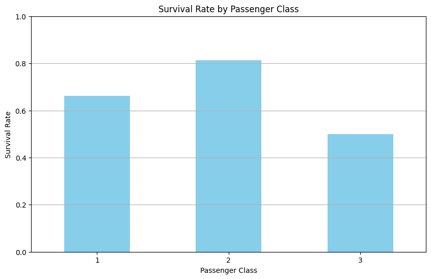

```python
# Calculate the survival rate by passenger class
survival_rate_by_class = df.groupby('Pclass')['Survived'].mean()

# Plot the bar chart
plt.figure(figsize=(10,6))
survival_rate_by_class.plot(kind='bar', color='skyblue')
plt.title('Survival Rate by Passenger Class')
plt.xlabel('Passenger Class')
plt.ylabel('Survival Rate')
plt.ylim(0,1)
plt.xticks(rotation=0)
plt.grid(axis='y')
plt.show()
```

**Explanation of Command:**

- survival_rate_by_class = df.groupby('Pclass')['Survived'].mean(): This command groups the DataFrame df by the 'Pclass' (passenger class) column and calculates the mean survival rate for each passenger class. The result is stored in the survival_rate_by_class variable as a Series object, where the index is the passenger class (1, 2, or 3) and the values are the corresponding survival rates.
- plt.figure(figsize=(10,6)): This command creates a new figure for the plot with a specific size (width=10, height=6) in inches.
- survival_rate_by_class.plot(kind='bar', color='skyblue'): This command plots a bar chart using the plot() method of the survival_rate_by_class Series. It specifies the kind of plot as a bar chart and sets the color of the bars to 'skyblue'.
- plt.title('Survival Rate by Passenger Class'): This command sets the title of the plot to 'Survival Rate by Passenger Class'.
- plt.xlabel('Passenger Class'): This command sets the label for the x-axis to 'Passenger Class'.
- plt.ylabel('Survival Rate'): This command sets the label for the y-axis to 'Survival Rate'.
- plt.ylim(0,1): This command sets the y-axis limits from 0 to 1 to ensure that the survival rate is displayed correctly.
- plt.xticks(rotation=0): This command sets the rotation of the x-axis labels to 0 degrees (horizontal) to improve readability.
- plt.grid(axis='y'): This command adds gridlines along the y-axis to the plot.
- plt.show(): This command displays the plot.

**Explanation of Output**

The output will be a bar chart showing the survival rate for each passenger class, with three bars representing each class (1, 2, and 3). The height of each bar represents the survival rate for that class.

#### **7. Conclusion**

Data cleaning is essential for producing accurate, reliable, and efficient analysis results by eliminating errors, missing values, and inconsistencies. Data exploration helps analysts understand the dataset's structure, identify patterns, and guide data cleaning, ensuring a sound basis for further analysis and informed decision-making. Together, these steps ensure the integrity and reliability of the insights derived from the data.